# Recruitment Overview

Luran Manfio

1/15/2020

#### The Objectives of this study are to:

#### 1.) Preform exploratory data analysis to discover statistically significant difference between traditional and modern recruitment methods. Areas of focus are recruitment rate, participant retention, and targeting.

#### 2.) preform similar analysis on the BEACH study to prove support the analysis found.

#### Below we have the numbers of participants we recruited per quarter broken down by how they heard of our study. We show both screened and consented participants over the course of the study.

## Participants screened

[figure not shown]

| how did you hear about us? | Total(n=103) |
| --- | --- |
| Didn’t Respond | 31 |
| Facebook | 23 |
| Flyer | 35 |
| Other | 14 |

## Consented Particiapnts

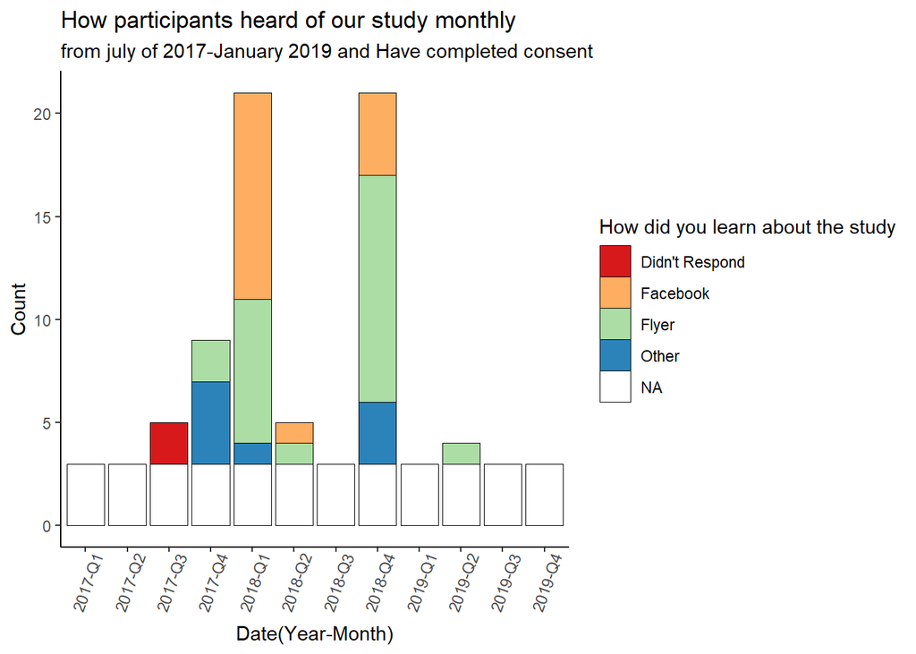

Fig6: Consented Participants Over Time

| how did you hear about us? | Total(n=47) |
| --- | --- |
| Didn’t Respond | 2 |
| Facebook | 15 |
| Flyer | 22 |
| Other | 8 |

#### results after preforming a proportions test on encounters for Facebook and Flyers by their consents.There is no statsitical signifigance between Facebook and Flyers on consented participants.

[output not shown]

## Recruitment over Facebook Ad activity

#### this figure shows our recruitment over our 7 rounds of Facebook ads only. This provides one of the most direct comparisions between recruitment methods.

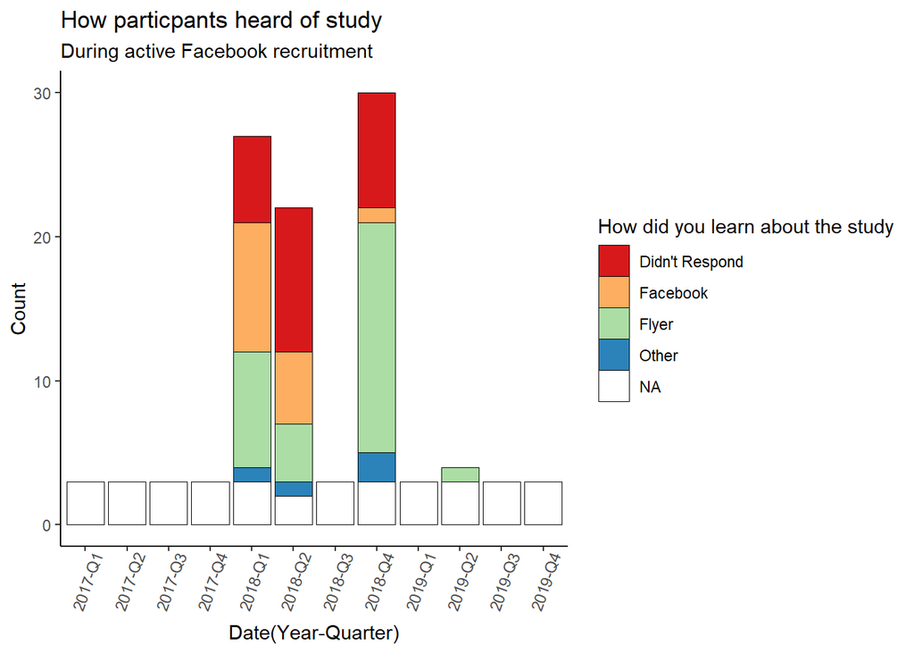

#### Proportion of participants recruited during the time of Facebook ads

| how did you hear about us? | Total(n=72) |
| --- | --- |
| Didn’t Respond | 24 |
| Facebook | 15 |
| Flyer | 29 |
| Other | 4 |

#### Proportion of participants Consented during Facebook ads running and a review of their BMI

| how did you hear about us? | Total(n=24) |
| --- | --- |
| Facebook | 8 |
| Flyer | 14 |
| Other | 2 |

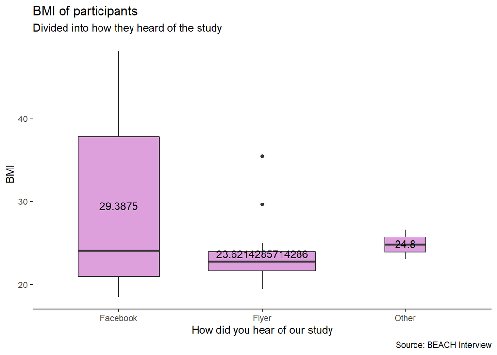

#### Review of the mean median and F-test of only participants recruited during the Facebook ads cycle

| n=24 | mean | median | F-test value | p-value |
| --- | --- | --- | --- | --- |
| BMI | 25.64 | 23 | 7.15 | 0.002 |

# Demographics

#### We focused our recruitment around 2 groups: Breastfeeding and Pregnant mother with BMI’s that would represent both normal and overweight participants. For this reason, we hoped to recruit a wide range of mother with varying BMI. With Facebooks targeted approch to recruitment, it should provide particpants within the both groups that fall within our desired ranges. We tested the variance between recruitment methods and provided a visualization of both BMI and age in boxplots. Below is a review of that research over the whole study without specifying pregnant or breastfeeding.

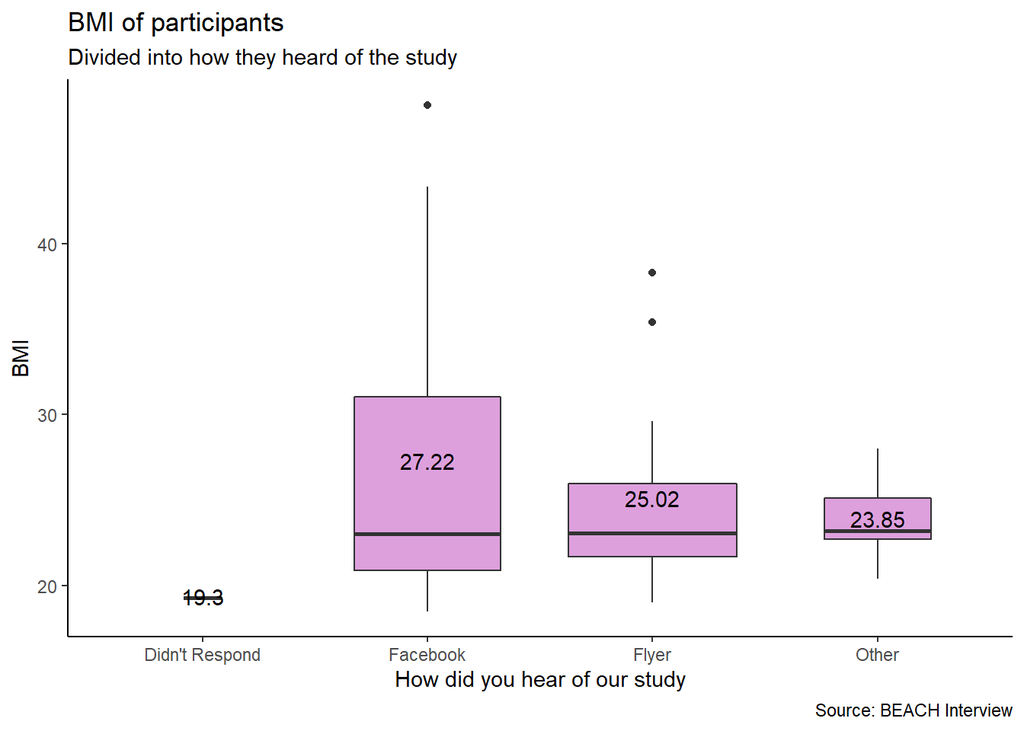

#### These tables below review our recruitment between BMI groups (overweight and normal weight):

| Encounter type | Count of overweight particiapnts(BMI>25) |
| --- | --- |
| Facebook | 6 |
| Flyer | 7 |
| Other | 2 |

| Encounter type | Count of normal weight particiapnts(BMI<25) |
| --- | --- |
| Facebook | 9 |
| Flyer | 13 |
| Other | 6 |

#### Below is a calculation of the mean median and varaince of BMI for all consented particpants.

| n=44 | mean | median | F-test value | p-value |
| --- | --- | --- | --- | --- |
| BMI | 25.43 | 23 | 2.61 | 0.05 |

#### We preformed the same tests with the age of the participants.

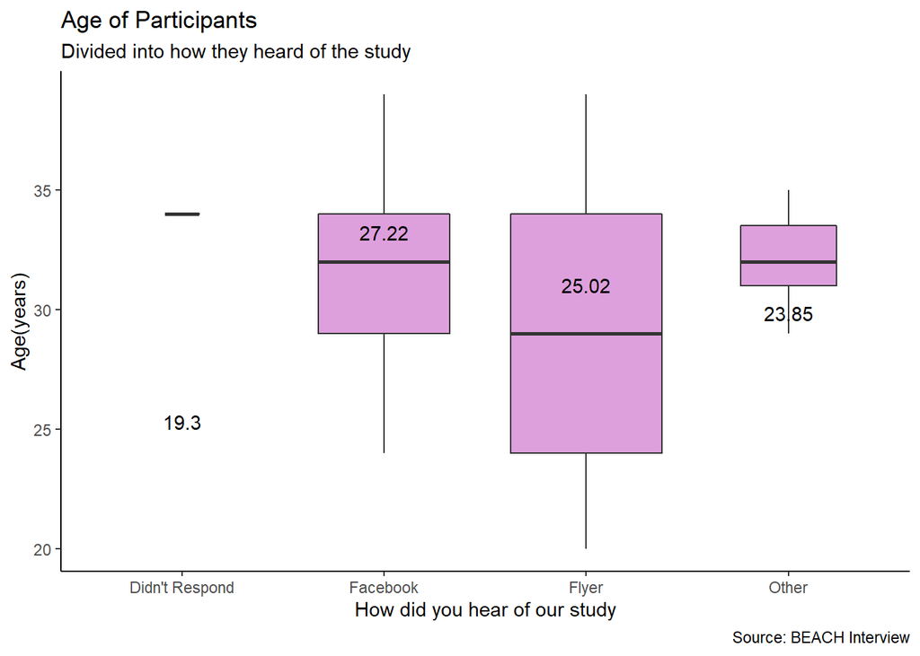

Fig9: Participant Age

#### Below we have the calcualtion of the mean median and variance of all consented parrticpants for age.

[output not shown]

## Review per Group

#### Following a review of the entire study we reviewed our two groups of interest: pregnant and breastfeeding.

### Pregnant Mothers

#### we first reviewed the particiapnts BMI.

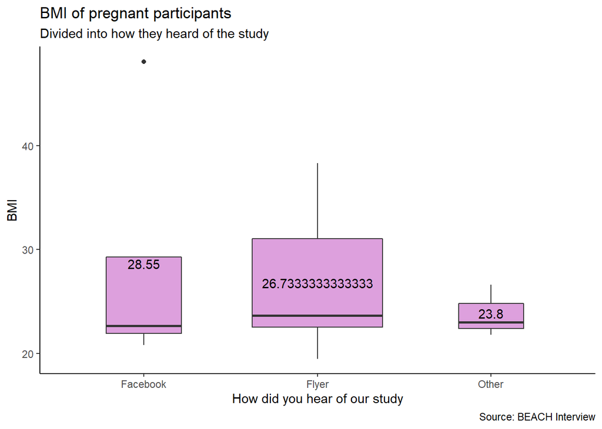

#### Below is the calculation of the mean median and variance of the pregnant groups BMI.

| n=19 | mean | median | F-test value | p-value |
| --- | --- | --- | --- | --- |
| BMI | 26.65 | 23 | 3.55 | 0.10 |

#### We preformed the same review for their age.

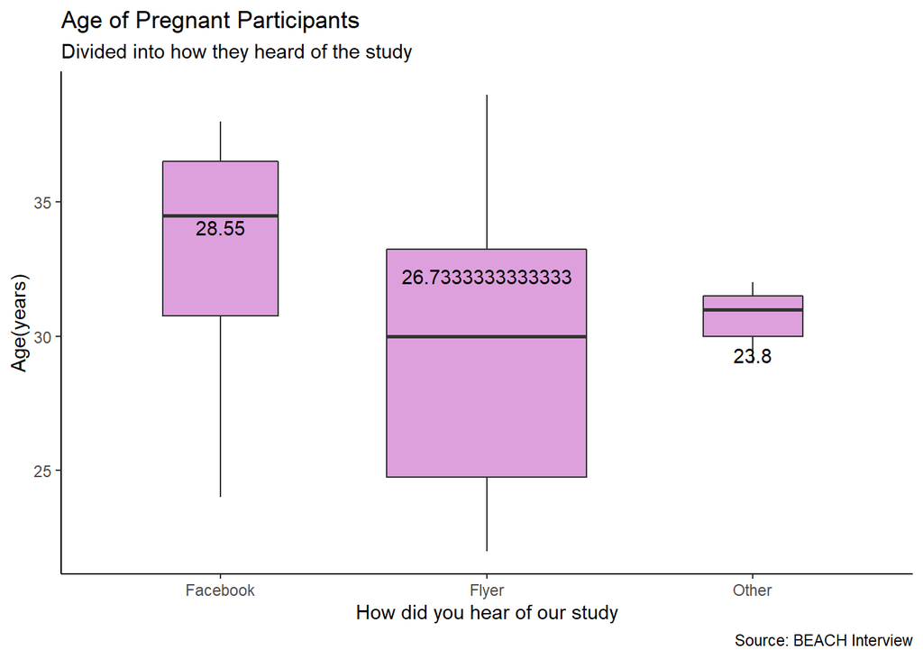

Fig9: Participant Age

#### Below is the calcuation of the mean median and variance of the ages for our pregnant group.

| n=19 | mean | median | F-test value | p-value |
| --- | --- | --- | --- | --- |
| Age | 30.58 | 31 | 1.38 | 0.60 |

### Breastfeeding mothers

#### we first reviewed the participants BMI.

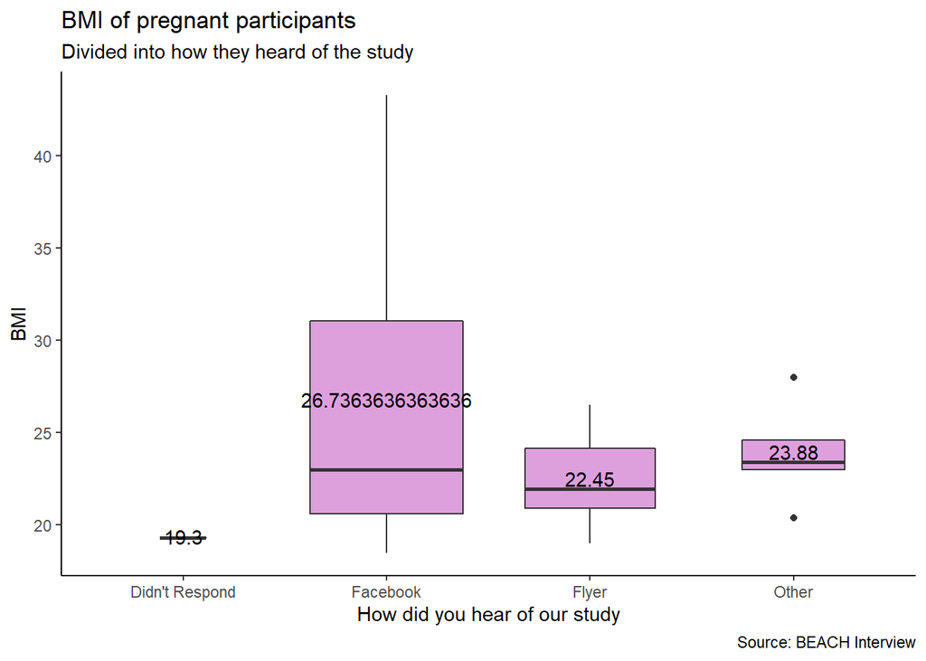

#### below we calculated our groups mean median and variance for their BMI.

[output not shown]

#### We preformed the same analysis for breastfeeding mother’s age. Our analysis is below.

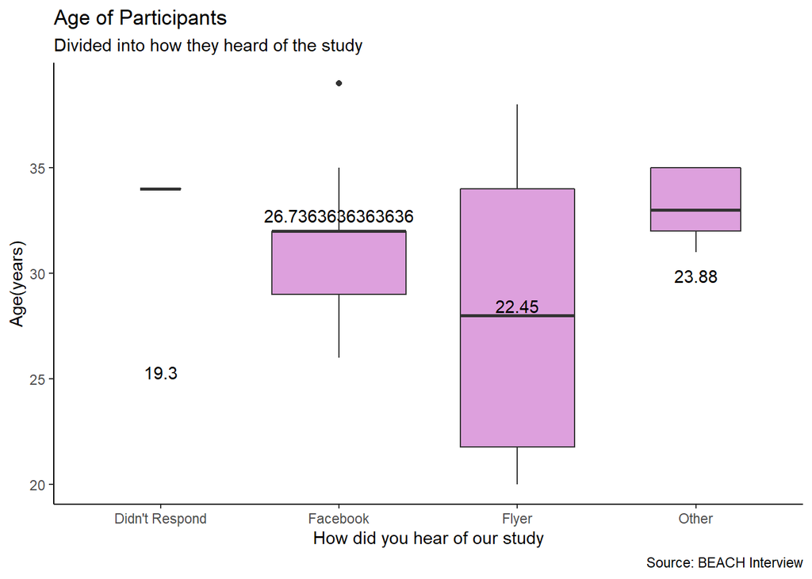

Fig9: Participant Age

#### below we calculated our groups mean median and variance for their age.

| n=25 | mean | median | F-test value | p-value |
| --- | --- | --- | --- | --- |
| Age | 30.77 | 32 | 0.27 | 0.64 |